# Gradedassingment

```python
# Step 1: Import necessary libraries
import pandas as pd

# Step 2: Load the dataset
# Replace 'dataset.csv' with the correct file path
df = pd.read_csv("Bank Personal Loan Modelling (1).csv")

# Step 3: Identify quantitative continuous variables
continuous_variables = ["Age", "Experience", "Income", "CCAvg", "Mortgage"]

# Step 4: Calculate IQR for each variable
iqr_values = {}
for var in continuous_variables:
    Q1 = df[var].quantile(0.25)
    Q3 = df[var].quantile(0.75)
    IQR = Q3 - Q1
    iqr_values[var] = IQR

# Step 5: Display the IQR for each variable
print("Interquartile Range (IQR) for Continuous Variables:")
for var, iqr in iqr_values.items():
    print(f"{var}: {iqr}")
```

```
Interquartile Range (IQR) for Continuous Variables:
Age: 20.0
Experience: 20.0
Income: 59.0
CCAvg: 1.8
Mortgage: 101.0
```

Age and Experience: IQR reflects the typical spread of customers in terms of age and professional experience. Income and CCAvg: Highlight spending behaviors; larger IQRs indicate diverse spending patterns. Mortgage: Larger IQR may indicate variability in loan amounts among customers.

```
First 5 Rows of the Dataset:
```

|  | ID | Age | Experience | Income | ZIP Code | Family | CCAvg | Education | Mortgage | Personal Loan | Securities Account | CD Account | Online | CreditCard |
| --- | --- | --- | --- | --- | --- | --- | --- | --- | --- | --- | --- | --- | --- | --- |
| 0 | 1 | 25 | 1 | 49 | 91107 | 4 | 1.6 | 1 | 0 | 0 | 1 | 0 | 0 | 0 |
| 1 | 2 | 45 | 19 | 34 | 90089 | 3 | 1.5 | 1 | 0 | 0 | 1 | 0 | 0 | 0 |
| 2 | 3 | 39 | 15 | 11 | 94720 | 1 | 1.0 | 1 | 0 | 0 | 0 | 0 | 0 | 0 |
| 3 | 4 | 35 | 9 | 100 | 94112 | 1 | 2.7 | 2 | 0 | 0 | 0 | 0 | 0 | 0 |
| 4 | 5 | 35 | 8 | 45 | 91330 | 4 | 1.0 | 2 | 0 | 0 | 0 | 0 | 0 | 1 |

```
Missing Values in Each Column:
ID                    0
Age                   0
Experience            0
Income                0
ZIP Code              0
Family                0
CCAvg                 0
Education             0
Mortgage              0
Personal Loan         0
Securities Account    0
CD Account            0
Online                0
CreditCard            0
dtype: int64

Summary Statistics for Income and CCAvg:
```

|  | Income | CCAvg |
| --- | --- | --- |
| count | 5000.000000 | 5000.000000 |
| mean | 73.774200 | 1.937938 |
| std | 46.033729 | 1.747659 |
| min | 8.000000 | 0.000000 |
| 25% | 39.000000 | 0.700000 |
| 50% | 64.000000 | 1.500000 |
| 75% | 98.000000 | 2.500000 |
| max | 224.000000 | 10.000000 |

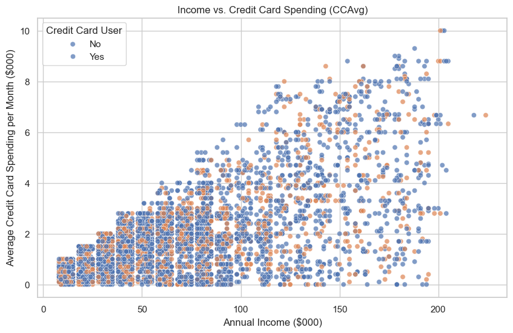

```
Pearson Correlation Coefficient between Income and CCAvg: 0.6460

Regression Analysis Summary:
                            OLS Regression Results
==============================================================================
Dep. Variable:                  CCAvg   R-squared:                       0.417
Model:                            OLS   Adj. R-squared:                  0.417
Method:                 Least Squares   F-statistic:                     3579.
Date:                Wed, 04 Dec 2024   Prob (F-statistic):               0.00
Time:                        22:42:12   Log-Likelihood:                -8535.4
No. Observations:                5000   AIC:                         1.707e+04
Df Residuals:                    4998   BIC:                         1.709e+04
Df Model:                           1
Covariance Type:            nonrobust
==============================================================================
                 coef    std err          t      P>|t|      [0.025      0.975]
------------------------------------------------------------------------------
const          0.1287      0.036      3.609      0.000       0.059       0.199
Income         0.0245      0.000     59.827      0.000       0.024       0.025
==============================================================================
Omnibus:                      216.093   Durbin-Watson:                   1.965
Prob(Omnibus):                  0.000   Jarque-Bera (JB):              501.094
Skew:                           0.259   Prob(JB):                    1.54e-109
Kurtosis:                       4.462   Cond. No.                         164.
==============================================================================

Notes:
[1] Standard Errors assume that the covariance matrix of the errors is correctly specified.
```

```python
# Import necessary libraries
import pandas as pd
import numpy as np
import matplotlib.pyplot as plt
import seaborn as sns
import statsmodels.api as sm

# For better visualization aesthetics
sns.set(style="whitegrid")

# Load the dataset
df = pd.read_csv("Bank Personal Loan Modelling (1).csv")

# Display the first few rows to verify
print("First 5 Rows of the Dataset:")
display(df.head())

# Check for missing values
print("\nMissing Values in Each Column:")
print(df.isnull().sum())

# Summary statistics for Income and CCAvg
print("\nSummary Statistics for Income and CCAvg:")
display(df[['Income', 'CCAvg']].describe())

# Scatter Plot: Income vs CCAvg
plt.figure(figsize=(10, 6))
sns.scatterplot(data=df, x='Income', y='CCAvg', hue='CreditCard', alpha=0.7)
plt.title("Income vs. Credit Card Spending (CCAvg)")
plt.xlabel("Annual Income ($000)")
plt.ylabel("Average Credit Card Spending per Month ($000)")
plt.legend(title='Credit Card User', labels=['No', 'Yes'])
plt.show()

# Calculate Pearson correlation coefficient
correlation = df['Income'].corr(df['CCAvg'])
print(f"Pearson Correlation Coefficient between Income and CCAvg: {correlation:.4f}")

# Regression Analysis
X = df['Income']
y = df['CCAvg']
X = sm.add_constant(X)
model = sm.OLS(y, X).fit()
print("\nRegression Analysis Summary:")
print(model.summary())
```

Positive Relationship: Higher-income customers tend to spend more on credit cards. Statistical Significance: The correlation and regression analysis confirm that the relationship is both strong and statistically significant. Practical Implications: Marketing strategies targeting higher-income segments may yield increased credit card usage and spending.

```
Total Customers: 5000
Customers Using Online Banking: 2984
Percentage of Customers Using Online Banking: 59.68%

Average Income Based on Online Banking Usage:
Online
0    72.978671
1    74.311662
Name: Income, dtype: float64
```

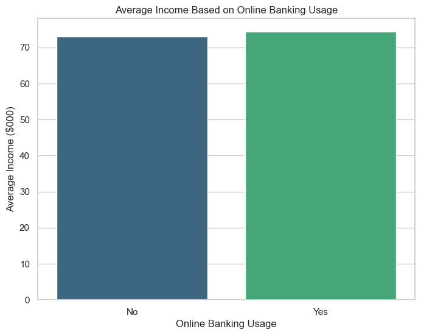

```
T-statistic: 1.0044
P-value: 0.3152
```

```python
# Import libraries
import pandas as pd
import numpy as np
import matplotlib.pyplot as plt
import seaborn as sns
from scipy.stats import ttest_ind

sns.set(style="whitegrid")

# Load the dataset
df = pd.read_csv("Bank Personal Loan Modelling (1).csv")

# Count of customers using online banking
online_count = df['Online'].sum()
total_customers = len(df)

print(f"Total Customers: {total_customers}")
print(f"Customers Using Online Banking: {online_count}")
print(f"Percentage of Customers Using Online Banking: {online_count / total_customers * 100:.2f}%")

# Compare income based on Online usage
income_comparison = df.groupby('Online')['Income'].mean()

print("\nAverage Income Based on Online Banking Usage:")
print(income_comparison)

# Bar plot for average income
plt.figure(figsize=(8, 6))
sns.barplot(x=['No', 'Yes'], y=income_comparison, palette="viridis")
plt.title("Average Income Based on Online Banking Usage")
plt.xlabel("Online Banking Usage")
plt.ylabel("Average Income ($000)")
plt.show()

# Perform a two-sample t-test
income_online = df[df['Online'] == 1]['Income']
income_offline = df[df['Online'] == 0]['Income']

t_stat, p_value = ttest_ind(income_online, income_offline)

print(f"T-statistic: {t_stat:.4f}")
print(f"P-value: {p_value:.4f}")
```

Usage Statistics:

```
Number of observations outside ±3σ: 2
```

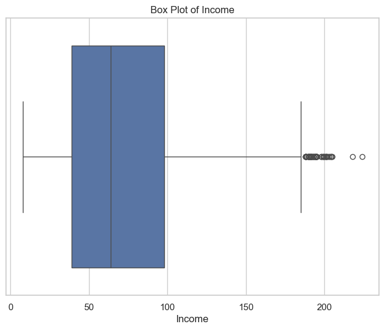

```python
import pandas as pd
import numpy as np
import matplotlib.pyplot as plt
import seaborn as sns

# Load the dataset
df = pd.read_csv("Bank Personal Loan Modelling (1).csv")

# Calculate the mean and standard deviation of Income
income_mean = df['Income'].mean()
income_std = df['Income'].std()

# Compute the z-scores for Income
df['Income_zscore'] = (df['Income'] - income_mean) / income_std

# Count observations outside ±3σ
outliers = df[(df['Income_zscore'] < -3) | (df['Income_zscore'] > 3)]
num_outliers = outliers.shape[0]

print(f"Number of observations outside ±3σ: {num_outliers}")

# Visualize outliers using a box plot
plt.figure(figsize=(8, 6))
sns.boxplot(x=df['Income'])
plt.title("Box Plot of Income")
plt.show()
```

Number of Outliers: This number indicates how many customers have an unusually high or low income relative to the rest of the dataset. Box Plot: Outliers appear as individual points beyond the whiskers. These observations may warrant further investigation for anomalies or exceptional cases.